# index

Author

Zehui Li & Mujin Li

# Library the Packages

```r
library(tidyverse)
library(ggplot2)
library(readxl)
library(lubridate)
library(gghighlight)
library(ggtext)
library(showtext)
library(viridisLite)
library(ggh4x)
library(geofacet)
```

# Load and Prepare the Data

- data for graph#1

```r
ind_strc<-read_excel("Chinese City Statistical Yearbook(partial).xlsx")

### select the data to be used
ind_3_share<-ind_strc%>%
  select(city,year,province,`Share of the Tertiary Sector in Gross Regional Product`,'Gross Regional Product (in billions of yuan)')%>%
  rename(tertiary_share = `Share of the Tertiary Sector in Gross Regional Product`,
         GRP = 'Gross Regional Product (in billions of yuan)')

### calculate the gross tertiary production and GRP by province per year
ind_3_share<-ind_3_share%>%
  mutate(tertiary = tertiary_share/100*GRP)%>%
  group_by(province, year)%>%
  summarize(total_tertiary = sum(tertiary, na.rm = TRUE),
            total_GRP = sum(GRP, na.rm = TRUE))

### calculate the share of tertiary industrial production
ind_3_share<-ind_3_share%>%
  mutate(tshare=total_tertiary/total_GRP*100)

### select the ETS's pilot province
ets_pilotcity<-ind_3_share%>%
  filter(province %in% c("Beijing","Tianjin","Shanghai", "Chongqing", "Hubei", "Guangdong"))

### remove the missiong value
ets_pilotcity<-ets_pilotcity%>%
  filter(total_tertiary!=0)

### change year in to times series formation
ets_pilotcity$year <- paste0(ets_pilotcity$year, "-01-01")
ets_pilotcity$year<-ymd(ets_pilotcity$year)

### remove the omit value
ets_pilotcity <- na.omit(ets_pilotcity)
```

- data for graph#2

```r
ind_strc<-read_excel("Chinese City Statistical Yearbook(partial).xlsx")

### select the useful column
diff_share<-ind_strc%>%
  select(city,year,province,`Share of the Tertiary Sector in Gross Regional Product`,'Gross Regional Product (in billions of yuan)',"Share of the Secondary Sector in Gross Regional Product")%>%
  rename(tertiary_share = "Share of the Tertiary Sector in Gross Regional Product",
         secondary_share = "Share of the Secondary Sector in Gross Regional Product",
         GRP = "Gross Regional Product (in billions of yuan)",
         name = "province")

### calculation of annual per-province total tertiary/secondary sector in GRP
diff_share<-diff_share%>%
  mutate(tertiary = tertiary_share/100*GRP,
         secondary = secondary_share/100*GRP)%>%
  group_by(name, year)%>%
  summarize(total_tertiary = sum(tertiary, na.rm = TRUE),
            total_secondary = sum(secondary, na.rm = TRUE))

diff_share<-left_join(x=china_prov_grid1,y=diff_share)

### change "year" into time series
diff_share$year <- paste0(diff_share$year, "-01-01")
diff_share$year<-ymd(diff_share$year)

### remove the missing value
diff_share_new<-diff_share%>%
  filter(name %in% c("Beijing","Tianjin","Shanghai", "Chongqing", "Hubei", "Guangdong"),
         total_tertiary!=0)
```

# Interpretation of Visualizations

China’s National Development and Reform Commission (NDRC) selected Beijing, Tianjin, Shanghai, Chongqing, Hubei, Guangdong, and Shenzhen as pilot provinces for the Carbon Emissions Trading Scheme (ETS) in 2013. ETS, which stands for Carbon Emissions Trading Scheme, aims to control greenhouse gas emissions, such as carbon dioxide, through market mechanisms, thus achieving emission control at a lower cost. However, as the world’s largest carbon emitter and one of the largest developing countries, China’s implementation of ETS serves the dual purpose of curbing carbon dioxide emissions and expediting the transformation of its economic development and industrial structure.

Most evaluations of China’s ETS policies primarily focus on emission reduction intensity and the outcomes of emission reduction efforts. Weiqing Huang et al.(2020) analyzed the ETS’s effects, considering emission reduction impact and cost. They studied the carbon emission intensity reduction rate in both pilot and non-pilot regions of ETS. Their findings revealed that pilot regions achieved an average carbon intensity reduction rate of 7.3%, while non-pilot regions reached an average reduction rate of 4.29%. Although these results highlight the ETS’s effectiveness in emission reduction, the question remains: has the ETS policy also contributed to industrial structural upgrading?

Industrial structural upgrading is crucial for optimizing and improving the industrial landscape(Liu et al., 2008). It encompasses changes in the proportion of different industries and enhancements in labor productivity, reflecting improvements in ‘structural efficiency.’ Graph#1 employs the tertiary industry’s share in Gross Regional Product (GRP) as a proxy for assessing changes in industrial structure. Conversely, Graph#2 compares the GRP of the secondary and tertiary industries. While Graph#1 uses the tertiary industry’s GRP share to depict shifts in industrial structure, Graph#2 examines the differences between the GRPs of the secondary and tertiary sectors.

BIBLIOGRAPHY [Weiqing Huang et al.(2020)](https://doi.org/10.1007/s11356-020-07818-0) [Liu et al.(2008)](https://doi.org/10.1007/s11356-020-07818-0)

# use ggplot to draw line chart

### Graph#1: Industrial Structure Changes in Six ETS Pilot Provinces from 1999 to 2021

uses the tertiary industry’s GRP share to depict shifts in industrial structure

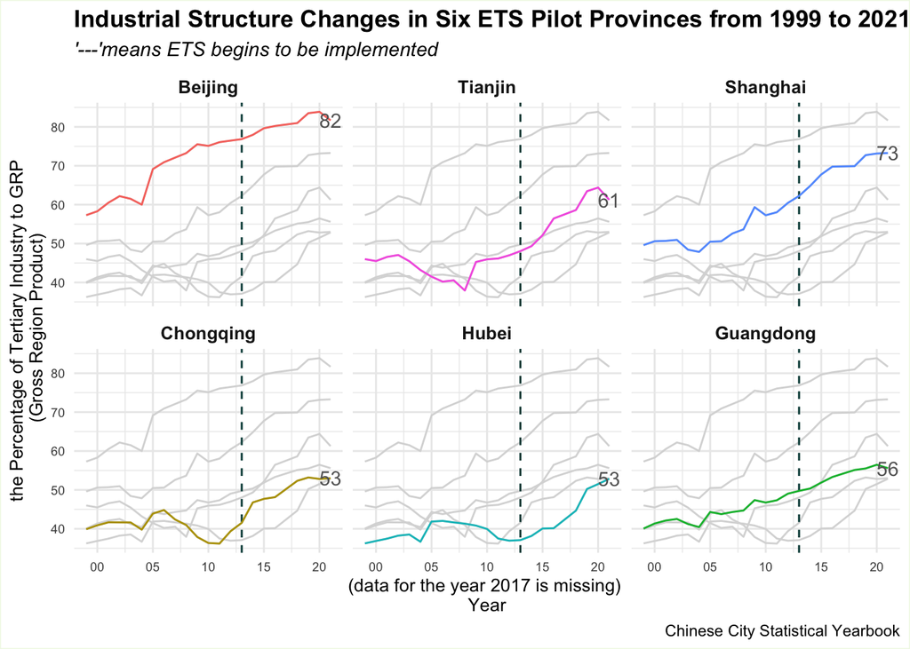

```r
ets_pilotcity%>%
  ggplot()+
  geom_vline(data= diff_share_new%>%
               group_by(name)%>%
              filter(year=="2013-01-01"),
               aes(xintercept=year),
             linetype = "dashed", color = "#004643")+
  geom_line(aes(x=year,y=tshare,color=province))+
  gghighlight(use_direct_label = FALSE,
              unhighlighted_params = list(colour="#d9d9d9"))+
  geom_text(data = ets_pilotcity %>%
              group_by(province)%>%
              slice_max(year),
            aes(x=year,y=tshare,label= round(tshare)),colour="#636363")+
  scale_x_date(date_labels = "%y") +
  facet_wrap(~  factor(province, levels=c("Beijing","Tianjin","Shanghai", "Chongqing", "Hubei", "Guangdong"))) +
  labs(x="(data for the year 2017 is missing) \nYear",
       y="the Percentage of Tertiary Industry to GRP \n(Gross Region Product)",
       title="Industrial Structure Changes in Six ETS Pilot Provinces from 1999 to 2021",
       subtitle  = "'---'means ETS begins to be implemented ",
       caption = "Chinese City Statistical Yearbook")+
  theme_minimal()+
  theme(axis.title= element_text(size = 10,face = "plain"),
        axis.text = element_text(size=7),
        strip.text.x = element_text(size = 10,face="bold"),
        legend.position = "none",
        plot.title = element_text(face = "bold"),
        plot.subtitle = element_text(face = "italic"),
        plot.background = element_rect(color = "#f0f9e8"))
```

### Graph#2: The Difference between Total Tertiary Porduct vs Secondary Product China’s ETS pilot province frome 1999 to 2021

examines the differences between the GRPs of the secondary and tertiary sectors

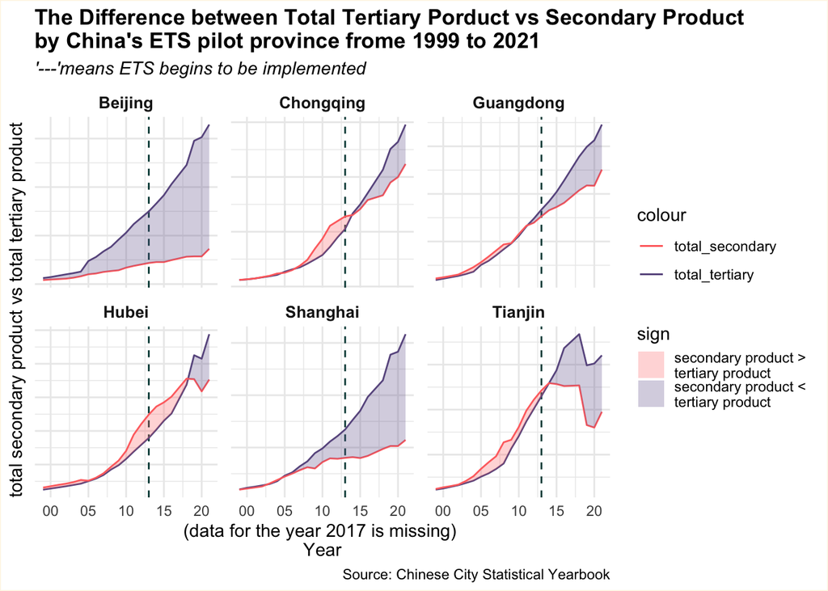

```r
diff_share_new%>%
  ggplot(aes(year))+
  geom_vline(data= diff_share_new%>%
               group_by(name)%>%
              filter(year=="2013-01-01"),
               aes(xintercept=year),
             linetype = "dashed", color = "#004643")+
  geom_line(aes(y=total_tertiary,color = "total_tertiary"))+
  geom_line(aes(y=total_secondary,color = "total_secondary"))+
  stat_difference(aes(ymin = total_tertiary, ymax = total_secondary),alpha = 0.3)+
  ### free the y scale to demonstrate the impact of ETS on induction structure
  facet_wrap(~ name,scales = "free_y",shrink = TRUE)+
  scale_color_manual(values = c("#ff6e6c", "#67568c")) +
  scale_fill_manual(
    values = c(
      colorspace::lighten("#ff6e6c"),
      colorspace::lighten("#67568c")),
    labels = c("secondary product > \ntertiary product", "secondary product < \ntertiary product")
  ) +
  scale_x_date(date_labels = "%y")+
  labs(title = "The Difference between Total Tertiary Porduct vs Secondary Product \nby China's ETS pilot province frome 1999 to 2021",
       subtitle = "'---'means ETS begins to be implemented ",
       caption = "Source: Chinese City Statistical Yearbook",
       x = "(data for the year 2017 is missing) \nYear",
       y = "total secondary product vs total tertiary product ")+
  theme_minimal()+
  theme(axis.text.y = element_blank(),
        strip.text.x = element_text(size = 10,face="bold"),
        plot.background = element_rect(color = "#fef6e4"),
        plot.title = element_text(face = "bold"),
        plot.subtitle = element_text(face = "italic"))
```

### Graph#3: Age Distribution of Full-time Teachers in Higher Education Institutions in China in 2021

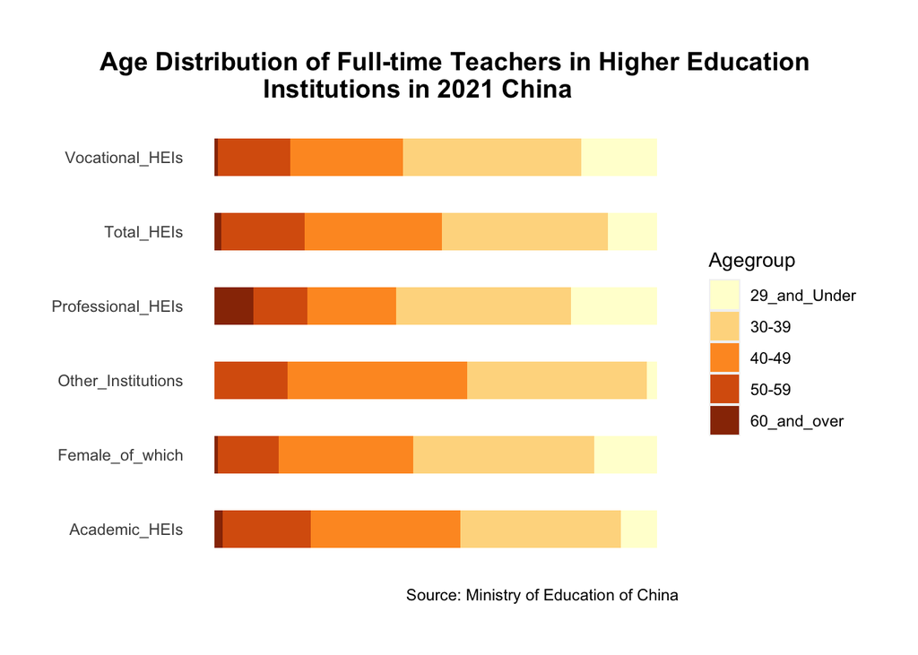

```r
ageproportion_HEIS <- read_excel("ageproportion_HEIS.xlsx")
Age_dis <- pivot_longer(ageproportion_HEIS,
                        names_to = "Agegroup",
                        values_to ="pplp",
                        2:6
                        )
ggplot(data = Age_dis,
       aes(x = ...1,
           y = pplp,
           fill= Agegroup)
       )+
geom_bar(
  stat = "identity",width = 0.5)+
coord_flip()+
theme(
  plot.margin = unit(
    c(1,1,1,1),"cm")
  )+
scale_fill_manual(
  values = c("#ffffd4","#fed98e","#fe9929","#d95f0e","#993404"))+
theme(
  axis.title.x = element_blank(),
axis.title.y = element_blank(),
axis.ticks.x = element_blank(),
axis.ticks.y = element_blank(),
axis.text.x = element_blank(),
panel.background = element_blank(),
plot.title = element_text(hjust = 0.4,face = "bold",size = 14)
)+
labs(
title = "Age Distribution of Full-time Teachers in Higher Education \nInstitutions in 2021 China",
caption = "Source: Ministry of Education of China"
)
```